# Case 31: Reliability and Factor Analysis

R3 (Attitude toward Employee Proficiency) and R6 (Attitude toward Operational Effectiveness)

Author

Julieta Diaz

Published

November 12, 2026

# Overview

When a construct is measured with several questions, the scale must be **valid** (it measures the intended construct) and **reliable** (the items measure it consistently) before the items are averaged into one score. This report checks both properties for the two multi-item scales in Case 31:

Table 1: Multi-item scales in Case 31

| Research question | Construct | Items | Scale |
| --- | --- | --- | --- |
| **R3** | Attitude toward employee proficiency | Q3 to Q6 | 5-point agreement (1 = strongly disagree, 5 = strongly agree) |
| **R6** | Attitude toward operational effectiveness | Q31 to Q34 | 5-point agreement |

The analysis follows four steps:

1. **Suitability:** are the items correlated enough to factor (correlations, KMO, Bartlett’s test)?
2. **Convergent validity:** do each scale’s items form **one** factor with strong loadings and communalities?
3. **Discriminant validity:** when all eight items are analyzed together, do they separate into the two intended constructs?
4. **Reliability:** is Cronbach’s alpha at least .70, and would dropping any item help?

**Scope**

This report only evaluates the **measurement quality** of the scales and decides whether a composite score should be created. Insights about what members think (answering R3 and R6) are a separate M13 activity.

# 1 Setup

```r
library(tidyverse)
library(haven)       # read the SPSS file
library(psych)       # KMO, Bartlett, fa(), fa.parallel(), alpha()
library(GPArotation) # oblimin rotation
library(knitr)
```

```r
efcu <- read_sav("data/Case 31 Data_efcu_1.sav") |>
  zap_labels()

r3_items <- efcu |> select(q3:q6) |> as.data.frame()     # employee proficiency
r6_items <- efcu |> select(q31:q34) |> as.data.frame()   # operational effectiveness
all_items <- bind_cols(r3_items, r6_items)

colSums(is.na(all_items))   # no missing values on these items
```

```
 q3  q4  q5  q6 q31 q32 q33 q34
  0   0   0   0   0   0   0   0
```

Table 2: Item wording

| Item | Wording |
| --- | --- |
| Q3 | Credit union employees are courteous |
| Q4 | Credit union employees are helpful |
| Q5 | Credit union employees are professional |
| Q6 | Credit union employees are always available |
| Q31 | Credit union personnel keep my financial information confidential |
| Q32 | The credit union is prompt in processing loan applications |
| Q33 | The credit union’s services meet the needs of its members |
| Q34 | Credit union loan applications are simple and easy to complete |

All 128 respondents answered every item, and none of these items is reverse-worded, so no recoding is needed.

```r
# Small helper to print suitability statistics as one row
suitability <- function(x, name) {
  r <- cor(x)
  k <- KMO(x)
  b <- cortest.bartlett(r, n = nrow(x))
  tibble(Scale = name,
         KMO = round(k$MSA, 3),
         `Bartlett chi-square` = round(b$chisq, 1),
         df = b$df,
         p = ifelse(b$p.value < .001, "<.001", sprintf("%.3f", b$p.value)),
         `Eigenvalues > 1` = sum(eigen(r)$values > 1))
}
```

# 2 R3: Attitude toward Employee Proficiency (Q3 to Q6)

## 2.1 Correlations and Suitability

```r
round(cor(r3_items), 2)
```

Table 3: R3 inter-item correlations

```
     q3   q4   q5   q6
q3 1.00 0.72 0.57 0.46
q4 0.72 1.00 0.68 0.67
q5 0.57 0.68 1.00 0.64
q6 0.46 0.67 0.64 1.00
```

```r
suitability(r3_items, "R3 (Q3 to Q6)")
```

Table 4: R3 suitability for factor analysis

| Scale | KMO | Bartlett chi-square | df | p | Eigenvalues > 1 |
| --- | --- | --- | --- | --- | --- |
| R3 (Q3 to Q6) | 0.775 | 263.6 | 6 | <.001 | 1 |

```r
KMO(r3_items)$MSAi |> round(2)   # item-level sampling adequacy
```

```
  q3   q4   q5   q6
0.76 0.73 0.84 0.79
```

The items correlate strongly with each other (from .46 to .72). The overall **KMO is 0.78** (“middling” to “meritorious”; above the .60 minimum), every item’s KMO is above .70, and **Bartlett’s test is significant**, so the correlation matrix is suitable for factor analysis.

## 2.2 Number of Factors

```
Parallel analysis suggests that the number of factors =  1  and the number of components =  NA
```

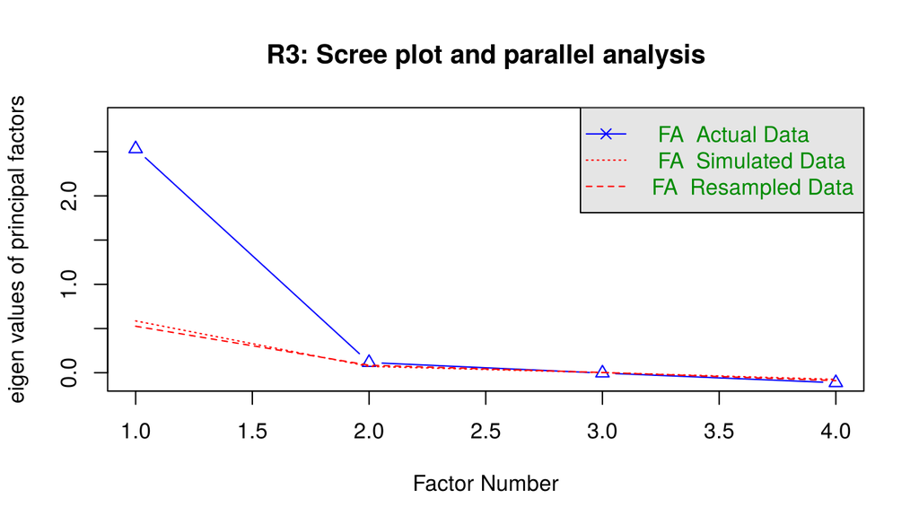

Figure 1: R3 scree plot with parallel analysis

```r
set.seed(2026)
r3_pa <- fa.parallel(r3_items, fm = "pa", fa = "fa",
                     main = "R3: Scree plot and parallel analysis")
```

Only the first eigenvalue (2.88) is above 1, the scree plot bends sharply after the first factor, and parallel analysis suggests **1** factor. All three criteria agree: **one factor**.

## 2.3 One-Factor Solution (Convergent Validity)

```r
r3_fa <- fa(r3_items, nfactors = 1, fm = "pa")   # principal axis factoring
print(r3_fa$loadings, cutoff = 0)
```

```
Loadings:
   PA1
q3 0.723
q4 0.922
q5 0.793
q6 0.729

                 PA1
SS loadings    2.532
Proportion Var 0.633
```

```r
tibble(Item = rownames(r3_fa$loadings),
       Loading = round(as.numeric(r3_fa$loadings), 3),
       Communality = round(r3_fa$communality, 3),
       Uniqueness = round(r3_fa$uniquenesses, 3))
```

Table 5: R3 loadings, communalities, and uniquenesses

| Item | Loading | Communality | Uniqueness |
| --- | --- | --- | --- |
| q3 | 0.723 | 0.522 | 0.478 |
| q4 | 0.922 | 0.849 | 0.151 |
| q5 | 0.793 | 0.628 | 0.372 |
| q6 | 0.729 | 0.532 | 0.468 |

Every loading is well above the common .50 guideline (from 0.72 to 0.92), every communality is above .50, and the single factor explains **63%** of the variance in the four items. A single factor with high loadings and communalities is evidence of **convergent validity**: Q3 to Q6 all reflect the same attitude toward employees.

## 2.4 Reliability

```r
r3_alpha <- psych::alpha(r3_items)
r3_alpha$total |> round(3)
```

|  | raw_alpha | std.alpha | G6(smc) | average_r | S/N | ase | mean | sd | median_r |
| --- | --- | --- | --- | --- | --- | --- | --- | --- | --- |
|  | 0.866 | 0.869 | 0.85 | 0.624 | 6.645 | 0.019 | 4.205 | 0.594 | 0.655 |

```r
tibble(Item = rownames(r3_alpha$alpha.drop),
       `Alpha if deleted` = round(r3_alpha$alpha.drop$raw_alpha, 3),
       `Item-total r (corrected)` = round(r3_alpha$item.stats$r.drop, 3),
       Mean = round(r3_alpha$item.stats$mean, 2),
       SD = round(r3_alpha$item.stats$sd, 2))
```

Table 6: R3 item statistics: alpha if item deleted and corrected item-total correlation

| Item | Alpha if deleted | Item-total r (corrected) | Mean | SD |
| --- | --- | --- | --- | --- |
| q3 | 0.852 | 0.657 | 4.35 | 0.66 |
| q4 | 0.785 | 0.823 | 4.31 | 0.70 |
| q5 | 0.824 | 0.733 | 4.08 | 0.66 |
| q6 | 0.853 | 0.673 | 4.08 | 0.79 |

The four-item employee proficiency scale has a **Cronbach’s alpha of 0.87**, well above the .70 threshold, indicating high internal consistency. The average inter-item correlation is 0.62. Dropping any item would **lower** alpha (to between 0.79 and 0.85), and every corrected item-total correlation is above .60, so all four items should be kept.

# 3 R6: Attitude toward Operational Effectiveness (Q31 to Q34)

## 3.1 Correlations and Suitability

```r
round(cor(r6_items), 2)
```

Table 7: R6 inter-item correlations

```
     q31  q32  q33  q34
q31 1.00 0.28 0.12 0.00
q32 0.28 1.00 0.22 0.39
q33 0.12 0.22 1.00 0.04
q34 0.00 0.39 0.04 1.00
```

```r
suitability(r6_items, "R6 (Q31 to Q34)")
```

Table 8: R6 suitability for factor analysis

| Scale | KMO | Bartlett chi-square | df | p | Eigenvalues > 1 |
| --- | --- | --- | --- | --- | --- |
| R6 (Q31 to Q34) | 0.496 | 39.3 | 6 | <.001 | 2 |

```r
KMO(r6_items)$MSAi |> round(2)
```

```
 q31  q32  q33  q34
0.49 0.50 0.60 0.46
```